# Movie_Recommendation_System_Modeling_Cosine_Similarity

```python
# Required Packages
import pandas as pd
import numpy as np

import unicodedata

from sklearn.impute import SimpleImputer
from sklearn.model_selection import train_test_split
from sklearn.linear_model import LinearRegression
from sklearn.metrics import mean_absolute_error, r2_score
from sklearn.preprocessing import StandardScaler
from sklearn.metrics.pairwise import cosine_similarity
from sklearn.feature_extraction.text import CountVectorizer

# Visualisation libraries

## Progress Bar
import progressbar

## Text
from colorama import Fore, Back, Style
from IPython.display import Image, display, Markdown, Latex, clear_output

## plotly
from plotly.offline import init_notebook_mode, iplot
import plotly.graph_objs as go
import plotly.offline as py
from plotly.subplots import make_subplots
import plotly.express as px

## seaborn
import seaborn as sns
sns.set_style("whitegrid")
sns.set_context("paper", rc={"font.size":12,"axes.titlesize":14,"axes.labelsize":12})

## matplotlib
import matplotlib.pyplot as plt
from matplotlib.font_manager import FontProperties
from matplotlib.patches import Ellipse, Polygon
import matplotlib.gridspec as gridspec
import matplotlib.colors
from pylab import rcParams
plt.style.use('seaborn-whitegrid')
import matplotlib as mpl
mpl.rcParams['figure.figsize'] = (17, 6)
mpl.rcParams['axes.labelsize'] = 14
mpl.rcParams['xtick.labelsize'] = 12
mpl.rcParams['ytick.labelsize'] = 12
mpl.rcParams['text.color'] = 'k'
%matplotlib inline

import warnings
warnings.filterwarnings("ignore")
```

[Home](https://hatefdastour.github.io/) / [Natural Language Processing](https://hatefdastour.github.io/portfolio/natural_language_processing/)

- [**Preprocessing**](https://hatefdastour.github.io/portfolio/natural_language_processing/Movie_Recommendation_System_Preprocessing.html)
- [**Modeling: Cosine Similarity**](https://hatefdastour.github.io/portfolio/natural_language_processing/Movie_Recommendation_System_Modeling_Cosine_Similarity.html)

In this article, we use an IMDB movie dataset from [Kaggle.com](https://www.kaggle.com/karrrimba/movie-metadatacsv). We will develop a model for recommending similar movies to a given movie.

```python
Data = pd.read_csv('movie_metadata/clean_movie_metadata.csv')
Data.head().style.hide_index()
```

| Movie_Title | Actor_1_Facebook_Likes | Actor_1_Name | Actor_2_Facebook_Likes | Actor_2_Name | Actor_3_Facebook_Likes | Actor_3_Name | Budget | Cast_Total_Facebook_Likes | Color | Content_Rating | Country | Director_Facebook_Likes | Director_Name | Duration | Genres | Gross | IMDB_Score | Language | Movie_Facebook_Likes | Num_Critic_For_Reviews | Num_User_For_Reviews | Num_Voted_Users | Plot_Keywords | Title_Year |
| --- | --- | --- | --- | --- | --- | --- | --- | --- | --- | --- | --- | --- | --- | --- | --- | --- | --- | --- | --- | --- | --- | --- | --- | --- |
| Avatar | 1000.000000 | CCH Pounder | 936.000000 | Joel David Moore | 855.000000 | Wes Studi | 237000000.000000 | 4834 | Color | PG-13 | USA | 0.000000 | James Cameron | 178.000000 | Action\|Adventure\|Fantasy\|Sci-Fi | 760505847.000000 | 7.900000 | English | 33000 | 723.000000 | 3054.000000 | 886204 | avatar\|future\|marine\|native\|paraplegic | 2009.000000 |
| Pirates of the Caribbean: At World's End | 40000.000000 | Johnny Depp | 5000.000000 | Orlando Bloom | 1000.000000 | Jack Davenport | 300000000.000000 | 48350 | Color | PG-13 | USA | 563.000000 | Gore Verbinski | 169.000000 | Action\|Adventure\|Fantasy | 309404152.000000 | 7.100000 | English | 0 | 302.000000 | 1238.000000 | 471220 | goddess\|marriage ceremony\|marriage proposal\|pirate\|singapore | 2007.000000 |
| Spectre | 11000.000000 | Christoph Waltz | 393.000000 | Rory Kinnear | 161.000000 | Stephanie Sigman | 245000000.000000 | 11700 | Color | PG-13 | UK | 0.000000 | Sam Mendes | 148.000000 | Action\|Adventure\|Thriller | 200074175.000000 | 6.800000 | English | 85000 | 602.000000 | 994.000000 | 275868 | bomb\|espionage\|sequel\|spy\|terrorist | 2015.000000 |
| The Dark Knight Rises | 27000.000000 | Tom Hardy | 23000.000000 | Christian Bale | 23000.000000 | Joseph Gordon-Levitt | 250000000.000000 | 106759 | Color | PG-13 | USA | 22000.000000 | Christopher Nolan | 164.000000 | Action\|Thriller | 448130642.000000 | 8.500000 | English | 164000 | 813.000000 | 2701.000000 | 1144337 | deception\|imprisonment\|lawlessness\|police officer\|terrorist plot | 2012.000000 |
| John Carter | 640.000000 | Daryl Sabara | 632.000000 | Samantha Morton | 530.000000 | Polly Walker | 263700000.000000 | 1873 | Color | PG-13 | USA | 475.000000 | Andrew Stanton | 132.000000 | Action\|Adventure\|Sci-Fi | 73058679.000000 | 6.600000 | English | 24000 | 462.000000 | 738.000000 | 212204 | alien\|american civil war\|male nipple\|mars\|princess | 2012.000000 |

## Initial Analysis

The columns of the dataset:

```python
def List_Print(Text, List, C = 'Blue', T = 'White'):
    BACK = {'Black': Back.BLACK, 'Red':Back.RED, 'Green':Back.GREEN, 'Yellow': Back.YELLOW, 'Blue': Back.BLUE,
            'Magenta':Back.MAGENTA, 'Cyan': Back.CYAN}
    FORE = {'Black': Fore.BLACK, 'Red':Fore.RED, 'Green':Fore.GREEN, 'Yellow':Fore.YELLOW, 'Blue':Fore.BLUE,
            'Magenta':Fore.MAGENTA, 'Cyan':Fore.CYAN, 'White': Fore.WHITE}
    print(BACK[C] + FORE[T] + Style.NORMAL + '%s:' % Text + Style.RESET_ALL + ' %s' % ', '.join(List))

List_Print('Columns', Data.columns.tolist())
```

[output not shown]

```python
Ratings = Data[['Movie_Title','Gross','IMDB_Score','Num_Critic_For_Reviews', 'Num_User_For_Reviews']]
Ratings.sort_values(by='Gross', ascending=False).head(10).style.hide_index()
```

| Movie_Title | Gross | IMDB_Score | Num_Critic_For_Reviews | Num_User_For_Reviews |
| --- | --- | --- | --- | --- |
| Avatar | 760505847.000000 | 7.900000 | 723.000000 | 3054.000000 |
| Titanic | 658672302.000000 | 7.700000 | 315.000000 | 2528.000000 |
| Jurassic World | 652177271.000000 | 7.000000 | 644.000000 | 1290.000000 |
| The Avengers | 623279547.000000 | 8.100000 | 703.000000 | 1722.000000 |
| The Dark Knight | 533316061.000000 | 9.000000 | 645.000000 | 4667.000000 |
| Star Wars: Episode I - The Phantom Menace | 474544677.000000 | 6.500000 | 320.000000 | 3597.000000 |
| Star Wars: Episode IV - A New Hope | 460935665.000000 | 8.700000 | 282.000000 | 1470.000000 |
| Avengers: Age of Ultron | 458991599.000000 | 7.500000 | 635.000000 | 1117.000000 |
| The Dark Knight Rises | 448130642.000000 | 8.500000 | 813.000000 | 2701.000000 |
| Shrek 2 | 436471036.000000 | 7.200000 | 205.000000 | 483.000000 |

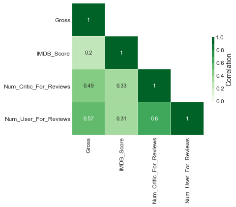

```python
def Correlation_Plot (Inp, Fig_Size = 12, annot_kws = 11):
    Correlation_Matrix = Inp.corr().round(2)
    mask = np.zeros_like(Correlation_Matrix)
    mask[np.triu_indices_from(mask)] = True
    for i in range(len(mask)):
        mask[i,i]=0
    fig, ax = plt.subplots(figsize=(Fig_Size, Fig_Size))
    sns.heatmap(Correlation_Matrix, ax=ax, mask=mask, annot=True, square=True,
                cmap =sns.color_palette("Greens", n_colors=10), linewidths = 0.2, vmin=0, vmax=1,
                cbar_kws={'label': 'Correlation', "aspect":30, "shrink": .4},  annot_kws={"size": annot_kws})
    return Correlation_Matrix



Rew_col_list=['Gross','IMDB_Score','Num_Critic_For_Reviews', 'Num_User_For_Reviews']
_ = Correlation_Plot (Ratings[Rew_col_list],6)
```

Pairplot

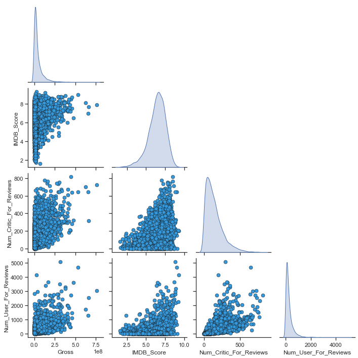

```python
sns.set(style="ticks", color_codes=True)
_ = sns.pairplot(Ratings, height=2.5, diag_kind="kde",
             plot_kws=dict(s=50, color="#3498db", edgecolor="k", linewidth=0.5),
             diag_kws=dict(shade=True), corner=True)
```

We can see that **the number of critics for reviews** and **the number of users for reviews** are highly correlated.

## Problem Description

We would like to convert the data into only two columns. That is one column only the movie titles and the other one all relevant information about a movie. Since we don't have any information on users' performance. This is a way to model this data.

**Modeling: Cosine Similarity**

```python
Drop_List=list()
Columns = Data.columns
for i in range(len(Columns)):
    if Columns[i].find('Facebook') != -1:
        Drop_List.append(Columns[i])
    if Columns[i].find('Num') != -1:
        Drop_List.append(Columns[i])

## Adding the rest of unrelated columns to the drop list
Drop_List=Drop_List+['Budget','Duration','Gross','IMDB_Score']
Data=Data.drop(columns=Drop_List)
```

This, the date reduces to

```python
Data = Data.reindex(columns=sorted(Data.columns,reverse=True))
Data.head().style.hide_index()
```

| Title_Year | Plot_Keywords | Movie_Title | Language | Genres | Director_Name | Country | Content_Rating | Color | Actor_3_Name | Actor_2_Name | Actor_1_Name |
| --- | --- | --- | --- | --- | --- | --- | --- | --- | --- | --- | --- |
| 2009.000000 | avatar\|future\|marine\|native\|paraplegic | Avatar | English | Action\|Adventure\|Fantasy\|Sci-Fi | James Cameron | USA | PG-13 | Color | Wes Studi | Joel David Moore | CCH Pounder |
| 2007.000000 | goddess\|marriage ceremony\|marriage proposal\|pirate\|singapore | Pirates of the Caribbean: At World's End | English | Action\|Adventure\|Fantasy | Gore Verbinski | USA | PG-13 | Color | Jack Davenport | Orlando Bloom | Johnny Depp |
| 2015.000000 | bomb\|espionage\|sequel\|spy\|terrorist | Spectre | English | Action\|Adventure\|Thriller | Sam Mendes | UK | PG-13 | Color | Stephanie Sigman | Rory Kinnear | Christoph Waltz |
| 2012.000000 | deception\|imprisonment\|lawlessness\|police officer\|terrorist plot | The Dark Knight Rises | English | Action\|Thriller | Christopher Nolan | USA | PG-13 | Color | Joseph Gordon-Levitt | Christian Bale | Tom Hardy |
| 2012.000000 | alien\|american civil war\|male nipple\|mars\|princess | John Carter | English | Action\|Adventure\|Sci-Fi | Andrew Stanton | USA | PG-13 | Color | Polly Walker | Samantha Morton | Daryl Sabara |

Converting the Data to string.

```python
Data=Data.astype(str)
```

More modifications on `genres` anc `plot_keywords` columns:

```python
### Genres
# converting to lower case
Data.Genres = Data.Genres.map(lambda x: x.lower())
# replacing '|' with ','
Data.Genres = Data.Genres.map(lambda x: x.split('|'))
# joining the string
Data.Genres = Data.Genres.str.join(' ')

### Plot_Keywords
# converting to lower case
Data.Plot_Keywords = Data.Plot_Keywords.map(lambda x: x.lower())
# replacing '|' with ','
Data.Plot_Keywords = Data.Plot_Keywords.map(lambda x: x.split('|'))
Data.Plot_Keywords = Data.Plot_Keywords.str.join(' ')
Data['Title_Year'] = Data['Title_Year'].astype(float).astype(int)
```

The resulting Data

```python
Data.head().style.hide_index()
```

| Title_Year | Plot_Keywords | Movie_Title | Language | Genres | Director_Name | Country | Content_Rating | Color | Actor_3_Name | Actor_2_Name | Actor_1_Name |
| --- | --- | --- | --- | --- | --- | --- | --- | --- | --- | --- | --- |
| 2009 | avatar future marine native paraplegic | Avatar | English | action adventure fantasy sci-fi | James Cameron | USA | PG-13 | Color | Wes Studi | Joel David Moore | CCH Pounder |
| 2007 | goddess marriage ceremony marriage proposal pirate singapore | Pirates of the Caribbean: At World's End | English | action adventure fantasy | Gore Verbinski | USA | PG-13 | Color | Jack Davenport | Orlando Bloom | Johnny Depp |
| 2015 | bomb espionage sequel spy terrorist | Spectre | English | action adventure thriller | Sam Mendes | UK | PG-13 | Color | Stephanie Sigman | Rory Kinnear | Christoph Waltz |
| 2012 | deception imprisonment lawlessness police officer terrorist plot | The Dark Knight Rises | English | action thriller | Christopher Nolan | USA | PG-13 | Color | Joseph Gordon-Levitt | Christian Bale | Tom Hardy |
| 2012 | alien american civil war male nipple mars princess | John Carter | English | action adventure sci-fi | Andrew Stanton | USA | PG-13 | Color | Polly Walker | Samantha Morton | Daryl Sabara |

Mimicing the process for actors and directors names:

```python
for i in range(len(Columns)):
    if Columns[i].find('Name') != -1:
        Data[Columns[i]] = Data[Columns[i]].map(lambda x: x.split(' '))
        Data[Columns[i]] = Data[Columns[i]].str.join('')
```

```python
Data.head().style.hide_index()
```

| Title_Year | Plot_Keywords | Movie_Title | Language | Genres | Director_Name | Country | Content_Rating | Color | Actor_3_Name | Actor_2_Name | Actor_1_Name |
| --- | --- | --- | --- | --- | --- | --- | --- | --- | --- | --- | --- |
| 2009 | avatar future marine native paraplegic | Avatar | English | action adventure fantasy sci-fi | JamesCameron | USA | PG-13 | Color | WesStudi | JoelDavidMoore | CCHPounder |
| 2007 | goddess marriage ceremony marriage proposal pirate singapore | Pirates of the Caribbean: At World's End | English | action adventure fantasy | GoreVerbinski | USA | PG-13 | Color | JackDavenport | OrlandoBloom | JohnnyDepp |
| 2015 | bomb espionage sequel spy terrorist | Spectre | English | action adventure thriller | SamMendes | UK | PG-13 | Color | StephanieSigman | RoryKinnear | ChristophWaltz |
| 2012 | deception imprisonment lawlessness police officer terrorist plot | The Dark Knight Rises | English | action thriller | ChristopherNolan | USA | PG-13 | Color | JosephGordon-Levitt | ChristianBale | TomHardy |
| 2012 | alien american civil war male nipple mars princess | John Carter | English | action adventure sci-fi | AndrewStanton | USA | PG-13 | Color | PollyWalker | SamanthaMorton | DarylSabara |

Converting the data to two columns only, `Movie_Title` and `Other`

```python
X = 'Movie_Title'
Y = list()
temp=Data.columns.tolist()
for i in range(len(temp)):
    if temp[i].find('Movie_Title') == -1:
         Y.append(temp[i])
del temp

Data['Text']=Data[Y[0]].astype(str)
for i in np.arange(1,len(Y)):
    Data['Text'] = Data['Text']+" "+ Data[Y[i]].astype(str)
del i
```

Droping Y columns

```python
Data=Data.drop(columns=Y)
del X, Y
```

```python
Data.head().style.hide_index()
```

| Movie_Title | Text |
| --- | --- |
| Avatar | 2009 avatar future marine native paraplegic English action adventure fantasy sci-fi JamesCameron USA PG-13 Color WesStudi JoelDavidMoore CCHPounder |
| Pirates of the Caribbean: At World's End | 2007 goddess marriage ceremony marriage proposal pirate singapore English action adventure fantasy GoreVerbinski USA PG-13 Color JackDavenport OrlandoBloom JohnnyDepp |
| Spectre | 2015 bomb espionage sequel spy terrorist English action adventure thriller SamMendes UK PG-13 Color StephanieSigman RoryKinnear ChristophWaltz |
| The Dark Knight Rises | 2012 deception imprisonment lawlessness police officer terrorist plot English action thriller ChristopherNolan USA PG-13 Color JosephGordon-Levitt ChristianBale TomHardy |
| John Carter | 2012 alien american civil war male nipple mars princess English action adventure sci-fi AndrewStanton USA PG-13 Color PollyWalker SamanthaMorton DarylSabara |

Instantiating and generating the count matrix using [CountVectorizer](https://scikit-learn.org/stable/modules/generated/sklearn.feature_extraction.text.CountVectorizer.html).

```python
vectorizer = CountVectorizer()
Matrix= vectorizer.fit_transform(Data['Text'])
# to view the entries run the following command
# vectorizer.get_feature_names()
```

Next, we are going to use [cosine_similarity](https://scikit-learn.org/stable/modules/generated/sklearn.metrics.pairwise.cosine_similarity.html) to find similarities.

```python
Similarity_Matrix = cosine_similarity(Matrix, dense_output=True)
print('This is a %i by %i matrix' % Similarity_Matrix.shape)
```

[output not shown]

## Movie Recommendations

```python
def recommend_movies(title, Number_Of_Recommendations= 10, Sim_Matrix=Similarity_Matrix):
    # Recommended Movies List
    Recommended_Movies_List  = []

    # the index of 'title' from the dataframe
    title_index = Data[Data['Movie_Title'].str.match(title)].index[0]

    # 'title' matches in descending order
    Title_Matches = pd.Series(Sim_Matrix[title_index]).sort_values(ascending = False)

    # Picking Number_Of_Recommendations movies
    Recom_index = list(Title_Matches.iloc[1:Number_Of_Recommendations].index)

    # populating the list with the titles of the best 10 matching movies
    for i in Recom_index:
        Recommended_Movies_List.append(list(Data.Movie_Title)[i].replace(u'\xa0', u''))

    Recommended_Movies_List=pd.DataFrame(Recommended_Movies_List,
                                         columns=['Recommended Titles']).style.hide_index()
    return Recommended_Movies_List
```

```python
recommend_movies('The Dark Knight Rises')
```

| Recommended Titles |
| --- |
| Premium Rush |
| Inception |
| The One |
| Man on a Ledge |
| Live Free or Die Hard |
| Alex Cross |
| The Cold Light of Day |
| G.I. Joe: The Rise of Cobra |
| Jack Reacher |

# References

1. [Kaggle Dataset: Movie Metadata](https://www.kaggle.com/karrrimba/movie-metadatacsv)